# Саенко_ФА

# Загрузим датасет из прошлого задания

```r
library(readxl)
df <- read_excel("C:/Users/Anastasia/Downloads/F00007630-WV6_Data_Ukraine_2011_Excel_v20180912.xlsx")
df <- df[,152:160]
```

```r
df <- na.omit(df)
```

# Часть 1. Разведовательный ФА

```r
library(foreign)
library(psych)
library(GGally)
library(GPArotation)
library(nFactors)
```

# Шаг 1. Анализ применимости ФА в целом

# Для этого посмотрим на корреляции между переменными ( также выведем их список, чтобы помнить, что есть что )

```r
colnames(df)
```

```
## [1] "V131: Democracy: Governments tax the rich and subsidize the poor."
## [2] "V132: Democracy: Religious authorities interpret the laws."
## [3] "V133: Democracy: People choose their leaders in free elections."
## [4] "V134: Democracy: People receive state aid for unemployment."
## [5] "V135: Democracy: The army takes over when government is incompetent."
## [6] "V136: Democracy: Civil rights protect people’s liberty from state oppression"
## [7] "V137: Democracy: The state makes people's incomes equal"
## [8] "V138: Democracy: People obey their rulers"
## [9] "V139: Democracy: Women have the same rights as men."
```

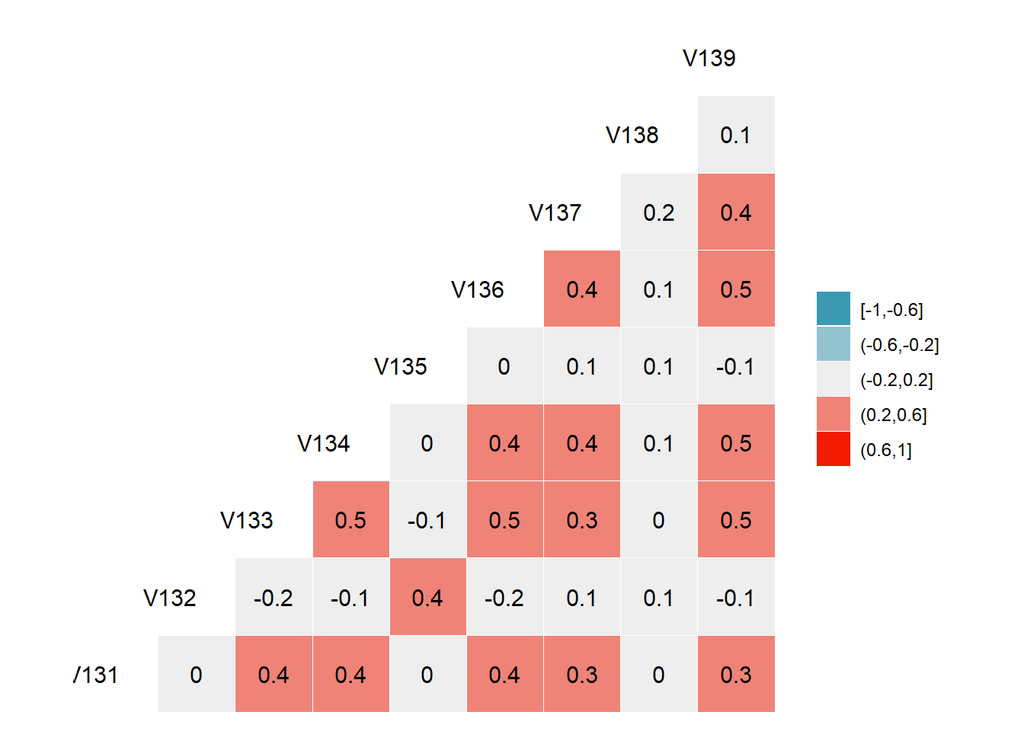

```r
colnames(df) <- c("V131","V132","V133","V134","V135", "V136","V137","V138", "V139")
ggcorr(df, nbreaks = 5, label = T, size = 4, hjust = 1)
```

Как можно увидеть из графика, есть переменные которые в общем-то не имеют высокой корреляции( например V138 ( неоюходимость подчинения правилам) и V136 ( ценность гражданских прав)). Однако есть и ряд переменных скоррелированных, однако не сильно ( больше 0,5 корреляций не наблюдается). Например, возьмем корреляцию между V139(равные права для женщин) и V136(гражданские права и защита от гос. давления) - 0.5, то есть относительно высокая по сравнению с остальными. Здесь можно сделать ровно такой же вывод как и при проведении МГК, соотвественно и предположение будет таким же, - логично предположить, что формируется по крайней мере две группы - ценностей более авторитарых ( армия и т.д например V132( власть религии) и V135( ценность армии и дисциплины) относительно других показателей сильно скоррелированы ( корр - 0.4)) и ценностей более демократических. Мы видим а) корреляции между ценностями относящимся к одной из групп ( предположительно) б) малую корреляцию между показатели двух разных групп. В рамках ФА такое наблюдение может также давать основания предположить, что можно будет выделить как минимум два факторы, которые и будут отражать эти разные ценности.

Проверим целесообразность тестом Kaiser-Meyer-Olkin:

```r
KMO(df)
```

```
## Kaiser-Meyer-Olkin factor adequacy
## Call: KMO(r = df)
## Overall MSA =  0.81
## MSA for each item =
## V131 V132 V133 V134 V135 V136 V137 V138 V139
## 0.86 0.57 0.83 0.85 0.57 0.83 0.83 0.68 0.86
```

# Шаг 2. Выбор количества факторов

Проведем несколько тестов для определения оптимального количества факторов

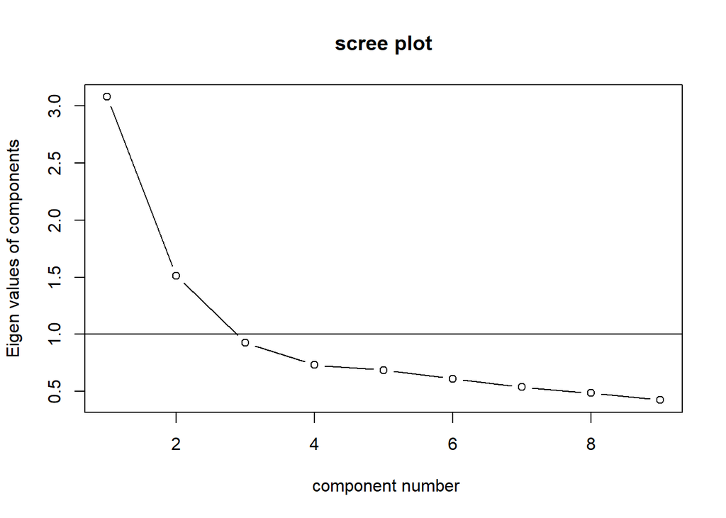

```r
corr <- cor(df)
VSS.scree(corr)
```

На графике необходимо отследить относительную скорость изменения собственных значений или вариации в зависимости от количества компонент. Здесь несовсем однозначно можно определить по визуализации: планомерное снижение начинается после значения 3 (значит надо взять два фактора, как и предпологалось), но с другой стороны и после 4 идет совсем замедленное снижение ( то есть надо было бы взять 3 фактора). Предположим, в соотвествие с нашей прошлой гипотезой, что факторов все же два и проверим это с помощью собственных значений.

```r
eigen(cor(df))$values
```

```
## [1] 3.0783391 1.5123081 0.9282684 0.7313011 0.6866768 0.6121115 0.5394319
## [8] 0.4865138 0.4250495
```

Как видим в общем-то гипотеза подтвердилась, первые два собственных значения превышают 1, а значит и необходимо взять 2 фактора. Проведем еще один формальный тест, проведя репликацию по параметрам выборки на 1000 независимых сэмплах ( с одниковыми параметрами к выборке), что тоже позволит оценить количество факторов.

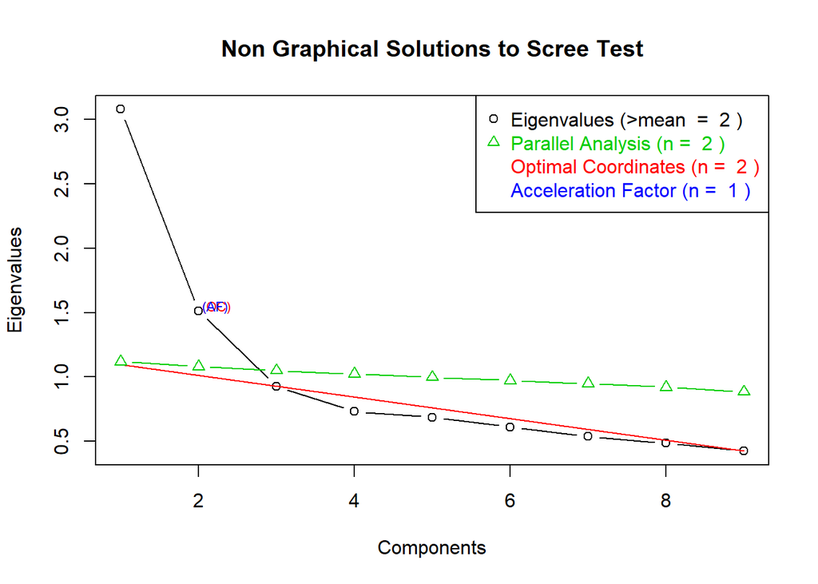

```r
eigen <- eigen(cor(df)) # get eigenvalues
p <- parallel(var = ncol(df), subject = nrow(df), rep = 1000)$eigen$mevpea
screeplot <- nScree(x=eigen$values, aparallel = p)
plotnScree(screeplot)
```

Как видим параллельное тестирование также подтверждает, что необходимо взять 2 фактора ( только в двух случаев результаты по изначальной выборке превышают результаты по репликациям)